# Transcripts

# Setup

Import required packages and helper functions.

```r
library(tidyverse)
library(swissparl)
library(furrr)
library(future)
# library(tidytext)
library(here)
source(here("Scripts/00_functions.R"))
```

# Import Data

```r
businesses_cleaned <- read_rds(here("Data/01_businesses_cleaned.rds"))
```

# Download Subjects

```r
get_subjects <- function(bsn, retries = 5, wait = 3) {
  folder <- here("Data/subjects")
  if (!dir.exists(folder)) {
    dir.create(folder)
  }

  out_file <- file.path(folder, paste0(bsn, ".rds"))
  if (file.exists(out_file)) {
    return(NULL)
  } # skip existing files

  for (attempt in 1:retries) {
    result <- try(
      get_data(
        table = "SubjectBusiness",
        BusinessShortNumber = bsn,
        Language = "DE"
      ),
      silent = TRUE
    )

    if (!inherits(result, "try-error")) {
      write_rds(result, out_file)
      # message("Downloaded ", bsn, " (attempt ", attempt, ")")
      return(TRUE)
    }

    # message("Error on ", bsn, " (attempt ", attempt, "): ", result)
    Sys.sleep(wait * attempt) # exponential backoff
  }

  # message("FAILED permanently: ", bsn)
  write(bsn, file = "failed_ids.txt", append = TRUE)
  return(FALSE)
}

plan(multisession, workers = 4)

# Start parallel jobs
fut <- future_walk(
  businesses_cleaned$BusinessShortNumber,
  get_subjects,
  .progress = TRUE
)

# WAIT UNTIL ALL JOBS ARE FINISHED
# value(fut)

plan(sequential)

if (!file.exists(here("Data/02_subjects.rds"))) {
  subjects <- map_dfr(
    list.files(here("Data/subjects"), full.names = TRUE),
    read_rds
  )
  write_rds(subjects, here("Data/02_subjects.rds"))
} else {
  subjects <- read_rds(here("Data/02_subjects.rds"))
}
```

Some businesses have no entries in `SubjectBusiness`, indicating they were never debated in either council.

```r
missing_bsn <- setdiff(
  businesses_cleaned$BusinessShortNumber,
  subjects$BusinessShortNumber
)
paste(length(missing_bsn), "businesses have no entries in SubjectBusiness.")
```

```
[1] "2678 businesses have no entries in SubjectBusiness."
```

# Download Transcripts

```r
get_transcripts <- function(sbj, retries = 5, wait = 3) {
  folder <- here("Data/transcripts")
  if (!dir.exists(folder)) {
    dir.create(folder)
  }

  out_file <- file.path(folder, paste0(sbj, ".rds"))
  if (file.exists(out_file)) {
    return(NULL)
  } # skip existing files

  for (attempt in 1:retries) {
    result <- try(
      get_data(
        table = "Transcript",
        IdSubject = as.double(sbj),
        Language = "DE"
      ),
      silent = TRUE
    )

    if (!inherits(result, "try-error")) {
      saveRDS(result, out_file)
      # message("Downloaded ", sbj, " (attempt ", attempt, ")")
      return(TRUE)
    }

    # message("Error on ", sbj, " (attempt ", attempt, "): ", result)
    Sys.sleep(wait * attempt) # exponential backoff
  }

  # message("FAILED permanently: ", sbj)
  write(sbj, file = "failed_ids.txt", append = TRUE)
  return(FALSE)
}

plan(multisession, workers = 4)

fut <- future_walk(
  subjects$IdSubject,
  get_transcripts,
  .progress = TRUE
)

# WAIT UNTIL ALL JOBS ARE FINISHED
# value(fut)

plan(sequential)

if (!file.exists(here("Data/02_transcripts.rds"))) {
  transcripts <- map_dfr(
    list.files(here("Data/transcripts"), full.names = TRUE),
    read_rds
  )
  write_rds(transcripts, here("Data/02_transcripts.rds"))
} else {
  transcripts <- read_rds(here("Data/02_transcripts.rds"))
}
```

# Inspect Transcripts

All meetings belong to either the National Council, the Council of States, or the United Federal Assembly. There are no committee pre-sessions. Good.

```r
transcripts |> count(MeetingCouncilAbbreviation)
```

```
# A tibble: 3 × 2
  MeetingCouncilAbbreviation      n
  <chr>                       <int>
1 N                          114057
2 S                           58182
3 V                             628
```

Check speaker details — which councils do they come from? I want only parliamentarians, other speakers (especially from the federal council) will be filtered out.

```r
transcripts |> count(CouncilId, CouncilName)
```

```
# A tibble: 5 × 3
  CouncilId CouncilName       n
      <int> <chr>         <int>
1         1 "Nationalrat" 81121
2         2 "Ständerat"   44238
3        98 ""              438
4        99 "Bundesrat"   18006
5        NA  <NA>         29064
```

Since the analysis centers around contributions from parliamentarians that can be attributed to a specific party (i.e. Parliamentary Group), entries without assigned parliamentary groups will be filtered out. These typically include speakers from the federal council, but also a few negligible contributions from parliamentarians without assigned groups (e.g. independents or technical remarks).

```r
transcripts |> count(ParlGroupName, CouncilName)
```

```
# A tibble: 28 × 3
   ParlGroupName                       CouncilName     n
   <chr>                               <chr>       <int>
 1 CVP-Fraktion                        Nationalrat  3683
 2 CVP-Fraktion                        Ständerat    3497
 3 Christlichdemokratische Fraktion    Ständerat      45
 4 Die Mitte-Fraktion. Die Mitte. EVP. Nationalrat  5554
 5 Die Mitte-Fraktion. Die Mitte. EVP. Ständerat    5675
 6 FDP-Liberale Fraktion               Nationalrat 12938
 7 FDP-Liberale Fraktion               Ständerat   11440
 8 Fraktion BD                         Nationalrat  1327
 9 Fraktion BD                         Ständerat     330
10 Fraktion CVP-EVP                    Nationalrat  3181
# ℹ 18 more rows
```

Check the distribution of speaker functions. Entries where no parliamentarian is assigned are typically moderations or technical remarks and will be filtered out.

```r
transcripts |> count(SpeakerFunction) |> arrange(n)
```

```
# A tibble: 17 × 2
   SpeakerFunction     n
   <chr>           <int>
 1 BK-F              133
 2 BK-M              305
 3 2VP-F             581
 4 2VP-M             975
 5 BPR-M            1031
 6 1VP-F            1095
 7 VPBR-F           1216
 8 BPR-F            1253
 9 VPBR-M           1390
10 1VP-M            2751
11 BR-F             5856
12 BR-M             7260
13 P-F             10026
14 P-M             20546
15 Mit-F           25273
16 <NA>            29055
17 Mit-M           64121
```

For demonstration, here are some transcripts without assigned speaker functions.

```r
transcripts |> filter(is.na(SpeakerFunction)) |> pull(Text) |> sample(10)
```

```
 [1] "<pd_text><p><i>Abstimmung - Vote </i>[GZ]</p>\n<p>[NAM][GZ]</p>\n<p>Für Annahme der Motion ... 17 Stimmen [GZ]</p>\n<p>Dagegen ... 22 Stimmen [GZ]</p>\n<p>(1 Enthaltung)</p>\n</pd_text>"
 [2] "<pd_text><p><b>La presidente</b> (Carobbio Guscetti Marina, presidente): Il Consiglio federale propone di respingere la mozione.</p>\n<p>[VS]</p>\n<p><i>Abstimmung - Vote </i>[GZ]</p>\n<p>[NAM][GZ]</p>\n<p>Für Annahme der Motion ... 101 Stimmen [GZ]</p>\n<p>Dagegen ... 86 Stimmen [GZ]</p>\n<p>…
 [3] "<pd_text><p><i>Zweite Abstimmung - Deuxième vote </i>[GZ]</p>\n<p>[NAM][GZ]</p>\n<p>Für den Antrag der Mehrheit ... 107 Stimmen[GZ]</p>\n<p>Für den Antrag der Minderheit II ... 85 Stimmen[GZ]</p>\n<p>(0 Enthaltungen)</p>\n</pd_text>"
 [4] "<pd_text><p><i>Zurückgezogen - Retiré</i></p>\n</pd_text>"
 [5] "<pd_text><p><b>Bundesbeschluss über die Volksinitiative \"für die Würde der landwirtschaftlichen Nutztiere (Hornkuh-Initiative)\"</b>[GZ]</p>\n<p><b>Arrêté fédéral relatif à l'initiative populaire \"pour la dignité des animaux de rente agricoles (initiative pour les vaches à cornes)\"</b>[GZ]<…
 [6] "<pd_text><p><i>Erste Abstimmung - Premier vote </i>[GZ]</p>\n<p>Für den Antrag Caroni ... 32 Stimmen [GZ]</p>\n<p>Für den neuen Antrag der Minderheit ... 9 Stimmen [GZ]</p>\n<p>(1 Enthaltung)</p>\n</pd_text>"
 [7] "<pd_text><p><i>Abstimmung - Vote</i></p>\n<p>[NAM]</p>\n<p>Für Annahme der Motion ... 106 Stimmen</p>\n<p>Dagegen ... 63 Stimmen</p>\n</pd_text>"
 [8] "<pd_text><p><i>Ausgabenbremse - Frein aux dépenses</i>[GZ]</p>\n<p>[VS][GZ]</p>\n<p><i>Abstimmung - Vote </i>[GZ]</p>\n<p>[NAM][GZ]</p>\n<p>Für Annahme der Ausgabe ... 193 Stimmen [GZ]</p>\n<p>Dagegen ... 1 Stimme [GZ]</p>\n<p>(1 Enthaltung)</p>\n<p>[VS]</p>\n<p><i>Das qualifizierte Mehr ist e…
 [9] "<pd_text><p><i>Abstimmung - Vote </i>[GZ]</p>\n<p>[NAM][GZ]</p>\n<p>Für den Antrag der Minderheit II ... 51 Stimmen[GZ]</p>\n<p>Dagegen ... 140 Stimmen[GZ]</p>\n<p>(0 Enthaltungen)</p>\n</pd_text>"
[10] "<pd_text><p><i>Abstimmung - Vote </i>[GZ]</p>\n<p>[NAM][GZ]</p>\n<p>Für den Antrag der Minderheit ... 30 Stimmen[GZ]</p>\n<p>Dagegen ... 13 Stimmen[GZ]</p>\n<p>(0 Enthaltungen)</p>\n<p>[VS]</p>\n<p><i>Übrige Bestimmungen angenommen </i>[GZ]</p>\n<p><i>Les autres dispositions sont adoptées</i><…
```

Check the language distribution of the transcripts. Italian transcripts make only about 1% of the data and will be removed from the analysis for practical reasons.

```r
transcripts |> count(LanguageOfText) |> mutate(share = n / sum(n)) |> arrange(n)
```

```
# A tibble: 4 × 3
  LanguageOfText     n   share
  <chr>          <int>   <dbl>
1 IT              1576 0.00912
2 FR             27852 0.161
3 <NA>           55505 0.321
4 DE             87934 0.509
```

Check vote entries — these will be filtered out since they hold no substantive content.

```r
transcripts |> filter(!is.na(VoteBusinessNumber)) |> pull(Text) |> sample(10)
```

```
 [1] "<pd_text><p><i>Gesamtabstimmung - Vote sur l'ensemble </i>[GZ]</p>\n<p>[NAM][GZ]</p>\n<p>Für Annahme des Entwurfes ... 97 Stimmen [GZ]</p>\n<p>Dagegen ... 87 Stimmen [GZ]</p>\n<p>(3 Enthaltungen)</p>\n<p>[VS]</p>\n</pd_text>"
 [2] "<pd_text><p><b>Präsident </b>(Stahl Jürg, Präsident): Der Bundesrat beantragt die Ablehnung des Postulates.</p>\n<p>[VS]</p>\n<p><i>Abstimmung - Vote </i>[GZ]</p>\n<p>[NAM][GZ]</p>\n<p>Für Annahme des Postulates ... 52 Stimmen [GZ]</p>\n<p>Dagegen ... 132 Stimmen [GZ]</p>\n<p>(4 Enthaltungen)<…
 [3] "<pd_text><p><i>Gesamtabstimmung - Vote sur l'ensemble</i></p>\n<p>[NAM]</p>\n<p>Für Annahme des Entwurfes ... 27 Stimmen</p>\n<p>Dagegen ... 9 Stimmen</p>\n<p>(4 Enthaltungen)</p>\n</pd_text>"
 [4] "<pd_text><p><i>Abs. 4 - Al. 4 </i>[GZ]</p>\n<p>[VS][GZ]</p>\n<p><i>Abstimmung - Vote </i>[GZ]</p>\n<p>[NAM][GZ]</p>\n<p>Für den Antrag der Mehrheit ... 107 Stimmen[GZ]</p>\n<p>Für den Antrag der Minderheit ... 86 Stimmen[GZ]</p>\n<p>(1 Enthaltung)</p>\n</pd_text>"
 [5] "<pd_text><p><i>Abstimmung - Vote </i>[GZ]</p>\n<p>Für Annahme der Motion ... 11 Stimmen [GZ]</p>\n<p>Dagegen ... 29 Stimmen [GZ]</p>\n<p>(1 Enthaltung) [PAGE 1258] </p>\n</pd_text>"
 [6] "<pd_text><p><i>Abstimmung - Vote </i>[GZ]</p>\n<p>[NAM][GZ]</p>\n<p>Für den Antrag der Einigungskonferenz ... 147 Stimmen[GZ]</p>\n<p>Dagegen ... 28 Stimmen[GZ]</p>\n<p>(2 Enthaltungen) [PAGE 2318] </p>\n</pd_text>"
 [7] "<pd_text><p><i>Abstimmung - Vote</i></p>\n<p>Für den Antrag der Mehrheit ... 24 Stimmen</p>\n<p>Für den Antrag der Minderheit ... 13 Stimmen</p>\n<p>(2 Enthaltungen)</p>\n</pd_text>"
 [8] "<pd_text><p><i>Gesamtabstimmung - Vote sur l'ensemble</i>[GZ]</p>\n<p>[NAM][GZ]</p>\n<p>Für Annahme des Entwurfes ... 110 Stimmen[GZ]</p>\n<p>Dagegen ... 81 Stimmen[GZ]</p>\n<p>(2 Enthaltungen)</p>\n</pd_text>"
 [9] "<pd_text><p><b>Präsidentin</b> (Kälin Irène, Präsidentin): Die Mehrheit der Kommission beantragt, der Initiative keine Folge zu geben. Eine Minderheit Nantermod beantragt, ihr Folge zu geben.</p>\n<p>[VS]</p>\n<p><i>Abstimmung - Vote </i>[GZ]</p>\n<p>[NAM][GZ]</p>\n<p>Für Folgegeben ... 82 Sti…
[10] "<pd_text><p><i>Zweite Abstimmung - Deuxième vote </i>[GZ]</p>\n<p>[NAM][GZ]</p>\n<p>Für den Antrag der Minderheit II ... 101 Stimmen[GZ]</p>\n<p>Für den Antrag der Minderheit I ... 83 Stimmen[GZ]</p>\n<p>(4 Enthaltungen)</p>\n</pd_text>"
```

Check entries with `[VS]` tags — these are presiding remarks not relevant to content analysis and will be removed. As follows are some examples for demonstration.

```r
transcripts |>
  filter(
    str_detect(Text, "\\[VS]")
  ) |>
  pull(Text) |>
  sample(10)
```

```
 [1] "<pd_text><p><b>Präsident </b>(Walter Hansjörg, Präsident): Der Antrag der Minderheit Reimann Maximilian ist zurückgezogen worden.</p>\n<p>[VS] [PAGE 919] </p>\n<p><i>Abstimmung - Vote</i></p>\n<p>[NAM]</p>\n<p>Für den Antrag Schneider-Schneiter ... 176 Stimmen</p>\n<p>Für den Antrag der Mehrhe…
 [2] "<pd_text><p><b>Bundesbeschluss über die Genehmigung und die Umsetzung des Notenaustauschs zwischen der Schweiz und der EU betreffend die Übernahme der Richtlinie (EU) 2017/853 zur Änderung der EU-Waffenrichtlinie (Weiterentwicklung des Schengen-Besitzstands)</b>[GZ]</p>\n<p><b>Arrêté fédéral p…
 [3] "<pd_text><p><b>Präsidentin</b> (Riniker Maja, Präsidentin): Die Kommission beantragt die Annahme der Motion. Der Bundesrat beantragt die Ablehnung der Motion. </p>\n<p>[VS]</p>\n<p><i>Abstimmung - Vote </i>[GZ]</p>\n<p>[NAM][GZ]</p>\n<p>Für Annahme der Motion ... 172 Stimmen [GZ]</p>\n<p>Dageg…
 [4] "<pd_text><p>Nous touchons au coeur de la réforme. L'amélioration de la réadaptation professionnelle est vraiment le pilier de la présente révision. Le Conseil fédéral veut que la rente n'entre en ligne de compte que lorsqu'il n'y a plus du tout de possibilité de réinsertion. Les mesures propos…
 [5] "<pd_text><p><b>Verordnung der Bundesversammlung zum Parlamentsressourcengesetz </b>[GZ]</p>\n<p><b>Ordonnance de l'Assemblée fédérale relative à la loi sur les moyens alloués aux parlementaires </b>[GZ]</p>\n<p>[VS][GZ]</p>\n<p><i>Abstimmung - Vote </i>[GZ]</p>\n<p>[NAM][GZ]</p>\n<p>Für Annahm…
 [6] "<pd_text><p><i>Gesamtabstimmung - Vote sur l'ensemble</i></p>\n<p>[NAM]</p>\n<p>Für Annahme des Entwurfes ... 188 Stimmen</p>\n<p>Dagegen ... 2 Stimmen</p>\n<p>(0 Enthaltungen)</p>\n<p>[VS]</p>\n</pd_text>"
 [7] "<pd_text><p><b>Bundesgesetz über die politischen Rechte (Transparenz bei der Politikfinanzierung)</b>[GZ]</p>\n<p><b>Loi fédérale sur les droits politiques (Transparence du financement de la vie politique)</b>[GZ]</p>\n<p>[VS][GZ]</p>\n<p><b>Art. 76c </b>[GZ]</p>\n<p><i>Antrag der Einigungskon…
 [8] "<pd_text><p><b>Übergangsbestimmung zur Änderung vom ...</b>[GZ]</p>\n<p><i>Antrag der Mehrheit </i>[GZ]</p>\n<p>Streichen</p>\n<p>[VS]</p>\n<p><i>Antrag der Minderheit </i>[GZ]</p>\n<p>(Hegglin Peter, Gapany, Hurni, Maillard, Wasserfallen Flavia)[GZ]</p>\n<p>Gemäss Nationalrat, aber: [GZ]</p>\…
 [9] "<pd_text><p><i>Detailberatung - Discussion par article </i>[GZ]</p>\n<p>[VS][GZ]</p>\n<p><b>Titel und Ingress, Ziff. I, II</b>[GZ]</p>\n<p><i>Antrag der Kommission </i>[GZ]</p>\n<p>Zustimmung zum Beschluss des Ständerates</p>\n<p>[VS]</p>\n<p><b>Titre et préambule, ch. I, II </b>[GZ]</p>\n<p><…
[10] "<pd_text><p><b>Schweizerische Zivilprozessordnung (Verbesserung der Praxistauglichkeit und der Rechtsdurchsetzung)</b>[GZ]</p>\n<p><b>Code de procédure civile (Amélioration de la praticabilité et de l'application du droit)</b>[GZ]</p>\n<p>[VS][GZ]</p>\n<p><b>Ziff. I Art. 53 Abs. 3</b><i> </i>[…
```

# Clean Transcripts

Filter transcripts to the relevant session range and remove entries that are not suitable for content analysis: Italian-language entries, Speakers outside National Council and Council of State (Especially Federal Council), vote records, unassigned speaker functions, and paragraphs with `[VS]` tags.

Clean the Data, so it is ready for further processing.

```r
sessions <- get_data(
  "Session",
  StartDate = c(">2015-01-01"),
  Language = "DE"
  )
```

```
   57 entries found
   Fetching data from table 'Session'
```

```r
sessions_cleaned <- sessions |>
  mutate(
    IdSession = as.character(ID),
    legislative_period = as.character(LegislativePeriodNumber)
  ) |>
  rename(session_start = StartDate, session_end = EndDate) |>
  select(IdSession, SessionName, TypeName, legislative_period, session_start, session_end)

transcripts_filtered <- transcripts |>
  left_join(sessions_cleaned, by = "IdSession") |>
  filter(
    legislative_period >= 50, # start with legislative period 50, which started in late 2015
    IdSession <= 5210, # end with Autumn session 2025, which is the most recent session
    LanguageOfText != "IT", # exclude Italian-language entries
    CouncilId %in% c(1, 2), # keep only Speakers from the National Council and Council of States
    !is.na(ParlGroupName), # exclude entries without assigned parliamentary groups
    is.na(VoteBusinessNumber), # exclude vote records
    !is.na(SpeakerFunction), # exclude moderation and technical remarks
    !str_detect(Text, "\\[VS]") # exclude paragraphs with VS (Vorsitzende) tags
  )

businesses_climate <- businesses_cleaned |>
  filter(business_tag_climate == TRUE) |>
  distinct(BusinessShortNumber) |>
  pull(BusinessShortNumber)

subjects_climate <- subjects |>
  filter(BusinessShortNumber %in% businesses_climate) |>
  distinct(IdSubject) |>
  pull(IdSubject)

transcripts_cleaned <- transcripts_filtered |>
  rename(transcript_id = ID) |>
  mutate(
    transcript_text = Text |>
      str_replace_all("\\[PAGE \\d+\\]", "") |> # remove pagination
      str_replace_all("\\[GZ]", "") |> # remove [GZ] tags (major caesura)
      str_squish(),
    transcript_word_count = str_count(transcript_text),
    business_tag_climate = if_else(
      IdSubject %in% subjects_climate,
      TRUE,
      FALSE
    ),
    meeting_id = as.character(MeetingVerbalixOid),
    council_id = as.character(CouncilId),
    canton_id = as.character(CantonId),
    meeting_date = as.Date(Start),
    ParlGroupName = case_when(
      ParlGroupAbbreviation %in% c("M-E", "BD") ~ "Die Mitte-Fraktion / CVP-& BD-Fraktion",
      .default = ParlGroupName
    )
  ) |>
  select(
    !c(
      VoteId,
      VoteBusinessNumber,
      VoteBusinessShortNumber,
      VoteBusinessTitle,
      Type,
      SortOrder,
      Start,
      End,
      Modified,
      StartTimeWithTimezone,
      EndTimeWithTimezone
    )
  )

write_rds(transcripts_cleaned, here("Data/02_transcripts_cleaned.rds"))
```

# Check Cleaned Transcripts

Session statistics:

```r
# session_stats <-
transcripts_cleaned |>
  group_by(IdSession) |>
  summarise(
    number_of_meetings = n_distinct(meeting_id),
    number_of_transcripts = n_distinct(transcript_id),
    number_of_businesses = n_distinct(IdSubject)
  )
```

```
# A tibble: 51 × 4
   IdSession number_of_meetings number_of_transcripts number_of_businesses
   <chr>                  <int>                 <int>                <int>
 1 5001                      24                  1009                  151
 2 5002                      29                  1454                  209
 3 5003                       5                   279                   18
 4 5004                      25                  1413                  203
 5 5005                      29                  1505                  250
 6 5006                      27                  1423                  143
 7 5007                      28                  1455                  270
 8 5008                       5                   286                   78
 9 5009                      26                  1196                  267
10 5010                      27                  1130                  172
# ℹ 41 more rows
```

Meeting statistics:

```r
transcripts_cleaned |>
  group_by(MeetingVerbalixOid) |>
  summarise(
    number_of_transcripts = n_distinct(transcript_id),
    number_of_businesses = n_distinct(IdSubject)
  )
```

```
# A tibble: 1,181 × 3
   MeetingVerbalixOid number_of_transcripts number_of_businesses
                <int>                 <int>                <int>
 1               2671                    22                    3
 2               2672                    13                    5
 3               2673                    69                    6
 4               2674                    33                    6
 5               2675                    46                    4
 6               2676                    31                    5
 7               2677                    75                    3
 8               2678                    37                   11
 9               2679                    78                   13
10               2680                    20                    5
# ℹ 1,171 more rows
```

# Create Paragraphs

Extract individual paragraphs from transcript texts using HTML `<p>` tags, then clean inline HTML markup and assign unique paragraph IDs.

```r
paragraphs_raw <- transcripts_cleaned |>
  mutate(
    paragraph_text = str_extract_all(transcript_text, "(?<=<p>)(.*?)(?=</p>)")
  ) |>
  unnest(paragraph_text)

paragraphs_cleaned <- paragraphs_raw |>
  group_by(transcript_id) |>
  mutate(
    paragraph_text = str_replace_all(paragraph_text, "<[^>]+>", ""), # remove HTML tags for italics and bold etc.
    paragraph_id = paste0(transcript_id, "-", row_number())
  ) |>
  ungroup() |>
  mutate(
    paragraph_word_count = str_count(paragraph_text, "\\S+")
  )

write_csv(paragraphs_cleaned, here("Data/02_paragraphs_cleaned.csv"))
```

Calculate Statistics

```r
n_paragraphs <- paragraphs_cleaned |>
  summarise(count = n()) |>
  pull(count)
write_rds(n_paragraphs, here("Outputs/02_n_paragraphs.rds"))
```

# Visualize

Plot paragraph length distribution:

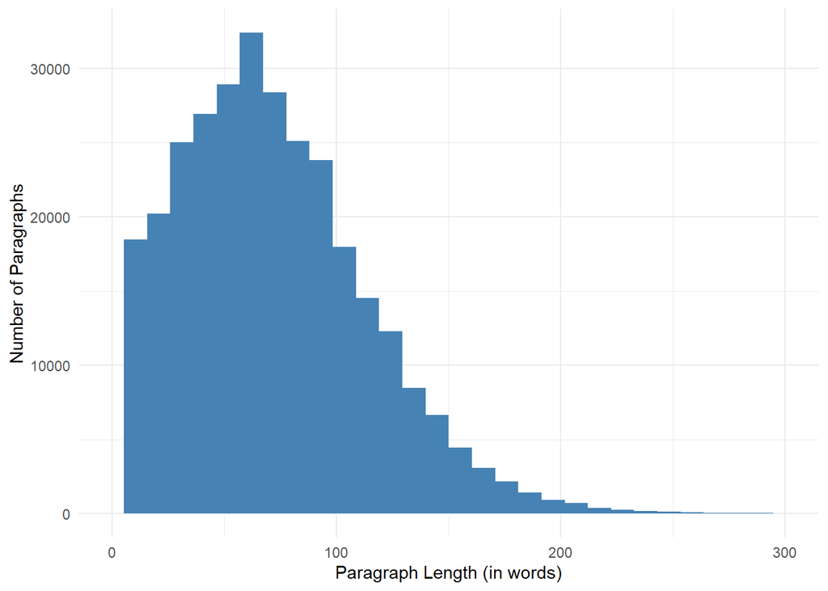

```r
plot_word_count_distribution(
  data = paragraphs_cleaned,
  output_path = "Outputs/02_paragraphs_cleaned_text_length_distribution.png"
)
```

Plot paragraph language distribution:

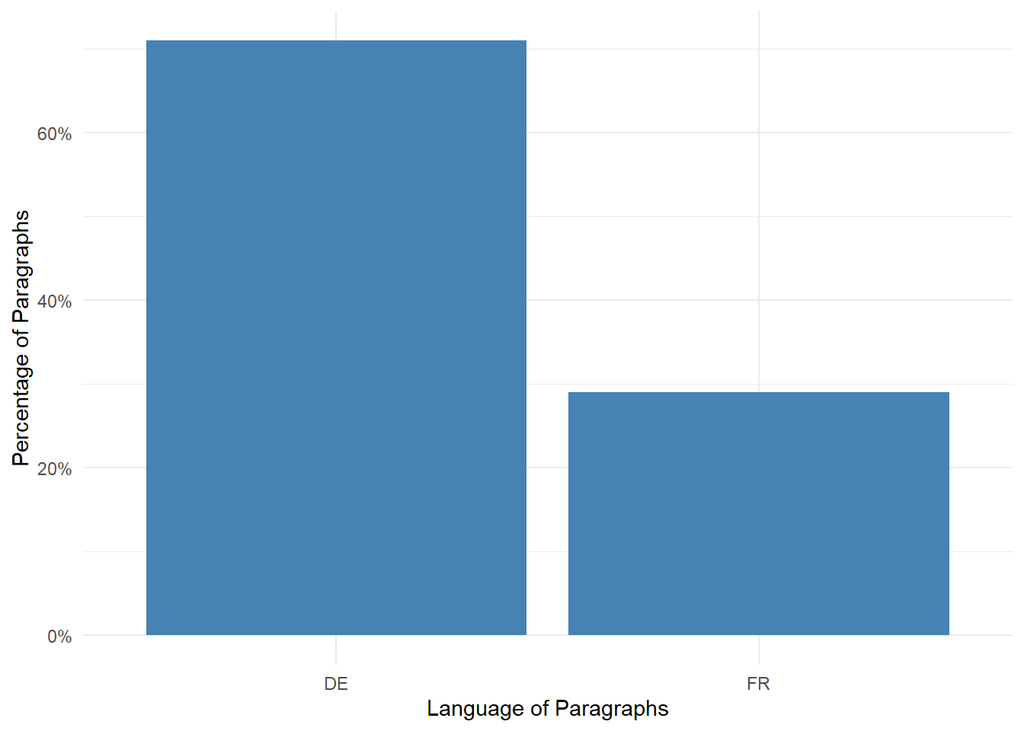

```r
plot_categorical_distribution(
  data = paragraphs_cleaned,
  group_col = "LanguageOfText",
  x_label = "Language of Paragraphs",
  output_path = "Outputs/02_paragraphs_cleaned_language_distribution.png"
)
```

# Join and Plot business information

```r
# create long table (a paragraph can have more than one bsn assigned)
paragraphs_subjects_long <-
  left_join(
    paragraphs_cleaned,
    subjects |> select(IdSubject, BusinessShortNumber),
    by = join_by(IdSubject),
    relationship = "many-to-many"
  ) |>
  left_join(
    businesses_cleaned |> select(BusinessShortNumber, BusinessTypeName, Title),
    by = join_by(BusinessShortNumber),
    relationship = "many-to-one"
  ) |>
  select(-IdSubject)

# summarise
paragraphs_subjects_summary <- paragraphs_subjects_long |>
  group_by(across(c(-BusinessShortNumber, -BusinessTypeName, -Title))) |>
  summarise(
    BusinessShortNumber = paste(BusinessShortNumber, collapse = " | "),
    BusinessTypeName = paste(BusinessTypeName, collapse = " | "),
    Title = paste(Title, collapse = " | ")
  )
```

Plot business type distribution:

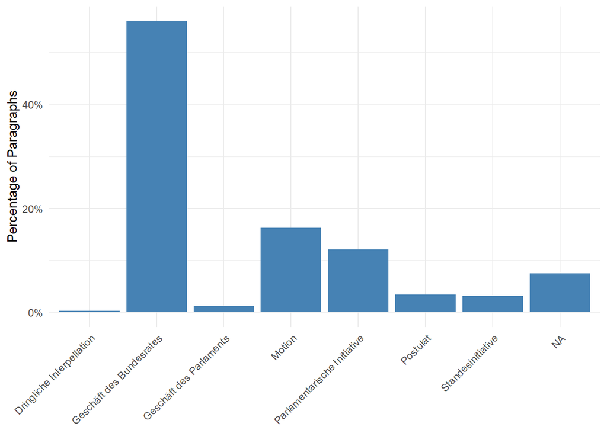

```r
df_grouped <- paragraphs_subjects_long |>
  group_by(across(all_of("BusinessTypeName"))) |>
  summarise(
    group_count = n(),
    pct = group_count / nrow(paragraphs_subjects_long),
    .groups = "drop"
  )

p <- ggplot(df_grouped, aes(x = .data[["BusinessTypeName"]], y = pct)) +
  geom_col(fill = "steelblue") +
  scale_y_continuous(labels = scales::percent_format()) +
  labs(
    x = NULL,
    y = "Percentage of Paragraphs",
  ) +
  theme_minimal() +
  theme(
    axis.text.x = element_text(angle = 45, hjust = 1)
  )
ggsave(here("Outputs/02_paragraphs_business_type_distribution.png"), p)
write_rds(p, here("Outputs/02_paragraphs_business_type_distribution.rds"))
p
```